# Children’s Health Crisis: Access to Care in a World Left Behind

A UNICEF Data Story on Acute Respiratory Infections Among Under-5 Children

Author

Data Analyst, UNICEF

Published

April 15, 2026

## Introduction

Every breath matters — especially for the **world’s youngest children**.

Acute Respiratory Infections (**ARI**) are one of the leading causes of child mortality globally, responsible for millions of preventable deaths each year among children **under the age of five**. Yet despite this enormous burden, millions of families in low-income countries never reach a health facility or provider when their child falls sick.

This report uses **UNICEF data** spanning over two decades and **126 countries** to explore a simple but urgent question:

> *When a child under 5 shows symptoms of ARI — are caregivers actually able to seek help?*

This is not just a health story. It is a story about **access, equity, and the urgent need for political will**.

## Data & Methodology

Three datasets from UNICEF were used in this analysis:

- **`unicef_indicator_1.csv`** — Percentage of under-5 children with ARI symptoms for whom care was sought, by country, year, and sex (1,220 rows across 126 countries).
- **`unicef_indicator_2.csv`** — Estimated AIDS-related death rate per 100,000 population (ages 10–19), used as supplementary context.
- **`unicef_metadata.csv`** — Country-level economic and demographic indicators including GDP per capita, population, life expectancy, and birth rate.

All data transformation was performed using **Polars** — chosen for its expressive lazy evaluation, speed on larger datasets, and clean API for chaining filters, joins, and aggregations. Visualisations were built exclusively with **plotnine**, a Python implementation of the Grammar of Graphics.

```python
import polars as pl
import pandas as pd
import geopandas as gpd
import urllib.request
import numpy as np
from plotnine import *
import warnings
warnings.filterwarnings("ignore")

# ── Load all three data files ──────────────────────────────────────────────
ind1 = pl.read_csv("unicef_indicator_1.csv")
ind2 = pl.read_csv("unicef_indicator_2.csv")
meta = pl.read_csv("unicef_metadata.csv")
```

## Exploratory Data Analysis

Before visualising, we examine each dataset to understand its shape, coverage, and quality.

```python
# ── Shape and coverage ─────────────────────────────────────────────────────
print("=== Indicator 1 (ARI Care-Seeking) ===")
print(f"  Rows       : {ind1.shape[0]}")
print(f"  Countries  : {ind1['country'].n_unique()}")
print(f"  Year range : {ind1['time_period'].min()} – {ind1['time_period'].max()}")
print(f"  Sex values : {ind1['sex'].unique().to_list()}")
print(f"  Null values: {ind1['obs_value'].null_count()}")

print("\n=== Metadata ===")
print(f"  Rows       : {meta.shape[0]}")
print(f"  Countries  : {meta['country'].n_unique()}")
print(f"  Year range : {meta['year'].min()} – {meta['year'].max()}")

# ── Descriptive statistics for ARI indicator (Total sex only) ─────────────
print("\n=== ARI obs_value descriptive stats (Total sex) ===")
stats = (
    ind1
    .filter(pl.col("sex") == "Total")
    .select(pl.col("obs_value"))
    .describe()
)
print(stats)

# ── Data quality: check for countries with very few observations ───────────
obs_counts = (
    ind1
    .filter(pl.col("sex") == "Total")
    .group_by("country")
    .agg(pl.len().alias("n_obs"))
    .sort("n_obs")
)
print(f"\nCountries with only 1 observation: "
      f"{obs_counts.filter(pl.col('n_obs') == 1).shape[0]}")
print(f"Countries with 5+ observations   : "
      f"{obs_counts.filter(pl.col('n_obs') >= 5).shape[0]}")
```

```
=== Indicator 1 (ARI Care-Seeking) ===
  Rows       : 1220
  Countries  : 126
  Year range : 2000 – 2024
  Sex values : ['Total', 'Female', 'Male']
  Null values: 0

=== Metadata ===
  Rows       : 13715
  Countries  : 211
  Year range : 1960 – 2024

=== ARI obs_value descriptive stats (Total sex) ===
shape: (9, 2)
┌────────────┬───────────┐
│ statistic  ┆ obs_value │
│ ---        ┆ ---       │
│ str        ┆ f64       │
╞════════════╪═══════════╡
│ count      ┆ 459.0     │
│ null_count ┆ 0.0       │
│ mean       ┆ 57.775381 │
│ std        ┆ 18.658182 │
│ min        ┆ 12.0      │
│ 25%        ┆ 44.0      │
│ 50%        ┆ 59.5      │
│ 75%        ┆ 71.4      │
│ max        ┆ 99.1      │
└────────────┴───────────┘

Countries with only 1 observation: 22
Countries with 5+ observations   : 37
```

## Global Picture: Who Gets Care?

The world map below shows each country’s **average ARI care-seeking rate** across all available years. A red-to-green colour gradient immediately reveals the geographic fault lines of child healthcare access.

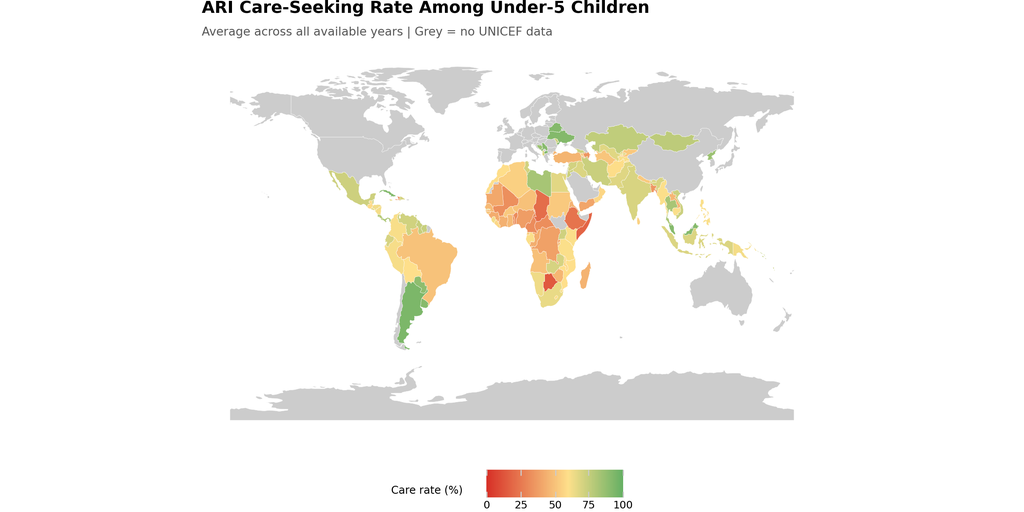

Figure 1: Average ARI care-seeking rate (%) by country. Grey = no data available.

```python
# ── Step 1: Compute per-country average (Total sex only) ──────────────────
# We filter to 'Total' to avoid double-counting Male + Female rows
map_avg = (
    ind1
    .filter(pl.col("sex") == "Total")
    .group_by(["country", "alpha_3_code"])
    .agg(pl.col("obs_value").mean().round(1).alias("avg_ari"))
).to_pandas()

# ── Step 2: Download Natural Earth world boundaries (GeoJSON) ─────────────
# We use the 110m resolution for a clean, fast render
url = (
    "https://raw.githubusercontent.com/nvkelso/"
    "natural-earth-vector/master/geojson/"
    "ne_110m_admin_0_countries.geojson"
)
with urllib.request.urlopen(url) as response:
    gdf = gpd.read_file(response)

# ── Step 3: Convert GeoDataFrame polygons to plotnine-compatible format ───
# plotnine needs a flat dataframe with long/lat/group columns
def gdf_to_polygon_df(gdf, name_col, iso_col):
    """
    Explode GeoDataFrame geometries into a row-per-vertex dataframe
    suitable for plotnine geom_polygon.
    """
    rows = []
    for _, row in gdf.iterrows():
        geom = row.geometry
        if geom is None:
            continue
        iso3  = row[iso_col]
        label = row[name_col]
        # Handle both Polygon and MultiPolygon geometries
        parts = [geom] if geom.geom_type == "Polygon" else list(geom.geoms)
        for g_idx, part in enumerate(parts):
            if part.geom_type == "Polygon":
                for x, y in part.exterior.coords:
                    rows.append({
                        "long"  : x,
                        "lat"   : y,
                        "group" : f"{iso3}_{g_idx}",
                        "region": label,
                        "iso3"  : iso3
                    })
    return pd.DataFrame(rows)

world_poly = gdf_to_polygon_df(gdf, "ADMIN", "ADM0_A3")

# ── Step 4: Left-join ARI data onto world polygons via ISO-3 code ──────────
# Left join keeps all world polygons; countries without ARI data stay grey
world_merged = world_poly.merge(map_avg, left_on="iso3", right_on="alpha_3_code", how="left")

# ── Step 5: Plot with plotnine ─────────────────────────────────────────────
(
    ggplot(world_merged, aes(x="long", y="lat", group="group", fill="avg_ari"))
    + geom_polygon(color="white", size=0.12)
    + scale_fill_gradient2(
        low="#d73027", mid="#fee08b", high="#1a9850",
        midpoint=60,
        na_value="#cccccc",
        name="Care rate (%)",
        limits=[0, 100]
    )
    + coord_fixed(1.3)
    + labs(
        title="ARI Care-Seeking Rate Among Under-5 Children",
        subtitle="Average across all available years | Grey = no UNICEF data",
        x="", y=""
    )
    + theme_void()
    + theme(
        plot_title=element_text(size=14, face="bold"),
        plot_subtitle=element_text(size=10, color="#555555"),
        legend_position="bottom",
        legend_title=element_text(size=9),
        figure_size=(12, 6)
    )
)
```

## The Best and the Worst

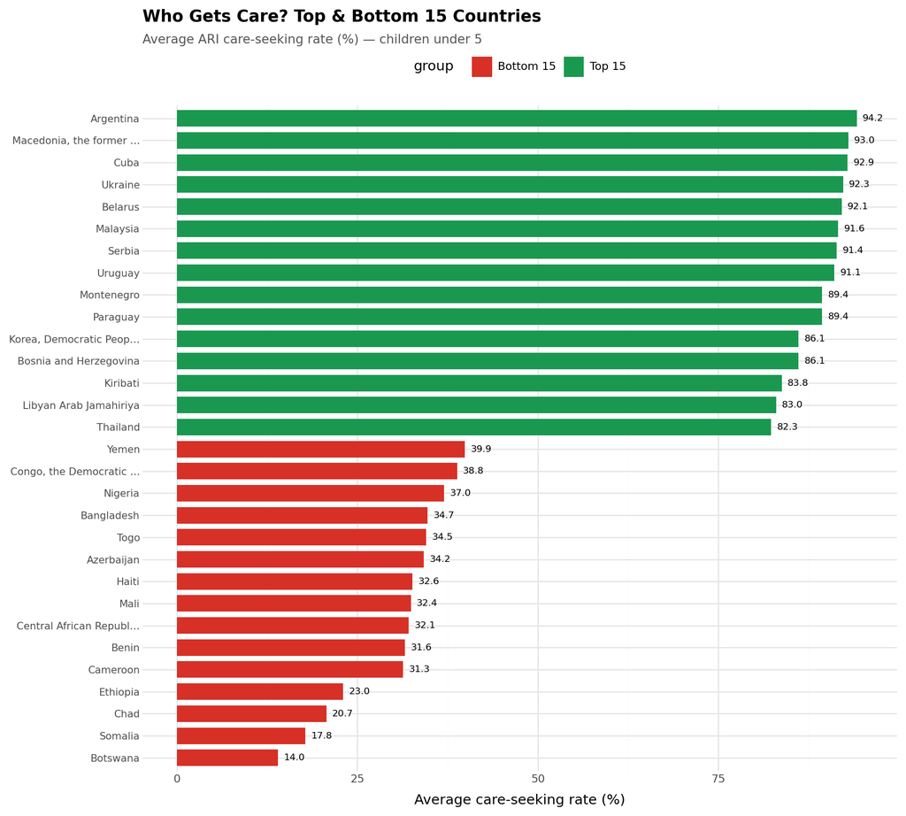

Figure 2: Top 15 and bottom 15 countries by average ARI care-seeking rate (%).

```python
# ── Compute country-level averages ─────────────────────────────────────────
country_avg = (
    ind1
    .filter(pl.col("sex") == "Total")
    .group_by(["country", "alpha_3_code"])
    .agg(pl.col("obs_value").mean().round(1).alias("avg_ari"))
    .sort("avg_ari", descending=True)
)

# ── Take top 15 and bottom 15, label each group ────────────────────────────
top15    = country_avg.head(15).with_columns(pl.lit("Top 15").alias("group"))
bottom15 = country_avg.tail(15).with_columns(pl.lit("Bottom 15").alias("group"))
bar_df   = pl.concat([top15, bottom15]).to_pandas()

# Truncate long country names for readability
bar_df["country"] = bar_df["country"].apply(
    lambda c: c[:22] + "…" if len(c) > 22 else c
)
bar_df = bar_df.sort_values("avg_ari")

(
    ggplot(bar_df, aes(x="reorder(country, avg_ari)", y="avg_ari", fill="group"))
    + geom_col(width=0.75)
    + geom_text(aes(label="avg_ari"), ha="left", size=7.5, nudge_y=0.8)
    + scale_fill_manual(
        values={"Top 15": "#1a9850", "Bottom 15": "#d73027"},
        name=""
    )
    + coord_flip()
    + labs(
        title="Who Gets Care? Top & Bottom 15 Countries",
        subtitle="Average ARI care-seeking rate (%) — children under 5",
        x="", y="Average care-seeking rate (%)"
    )
    + theme_minimal()
    + theme(
        plot_title=element_text(size=13, face="bold"),
        plot_subtitle=element_text(size=10, color="#555555"),
        legend_position="top",
        axis_text_y=element_text(size=8),
        figure_size=(10, 9)
    )
)
```

## Wealth and Health: Is There a Link?

```
Scatter dataset: 448 country-year observations after join
```

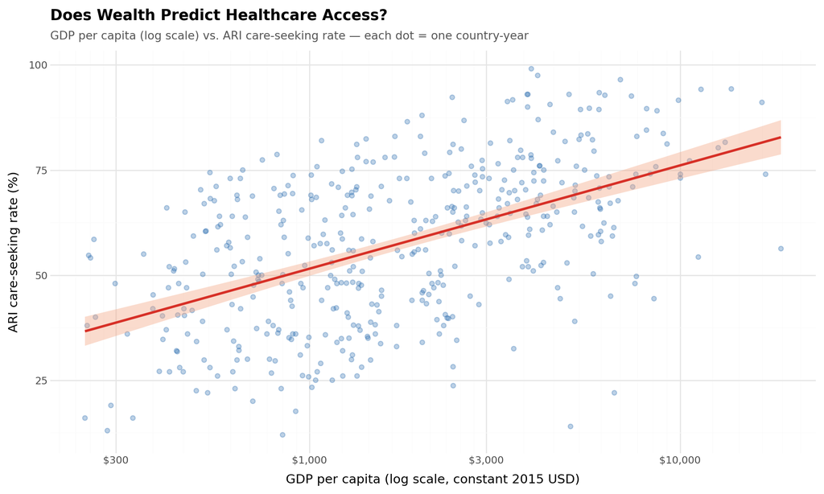

Figure 3: GDP per capita (log scale) vs. ARI care-seeking rate. Each dot = one country-year. Red line = linear regression with 95% CI.

```python
# ── Join indicator 1 with metadata on alpha_3_code + year ─────────────────
# We use an inner join to keep only country-years present in both datasets.
# This gives us economic context (GDP) for each ARI observation.
scatter_df = (
    ind1
    .filter(pl.col("sex") == "Total")
    .join(
        meta.select([
            "alpha_3_code", "year",
            "GDP per capita (constant 2015 US$)",
            "Life expectancy at birth, total (years)"
        ]),
        left_on=["alpha_3_code", "time_period"],
        right_on=["alpha_3_code", "year"],
        how="inner"
    )
    .rename({
        "GDP per capita (constant 2015 US$)"      : "gdp_pc",
        "Life expectancy at birth, total (years)"  : "life_exp"
    })
    .filter(pl.col("gdp_pc").is_not_null())
    .to_pandas()
)

print(f"Scatter dataset: {scatter_df.shape[0]} country-year observations after join")

(
    ggplot(scatter_df, aes(x="gdp_pc", y="obs_value"))
    + geom_point(alpha=0.3, color="#2166ac", size=1.8)
    + geom_smooth(method="lm", color="#d73027", fill="#f4a582", size=1.2)
    + scale_x_log10(labels=lambda l: [f"${x:,.0f}" for x in l])
    + labs(
        title="Does Wealth Predict Healthcare Access?",
        subtitle="GDP per capita (log scale) vs. ARI care-seeking rate — each dot = one country-year",
        x="GDP per capita (log scale, constant 2015 USD)",
        y="ARI care-seeking rate (%)"
    )
    + theme_minimal()
    + theme(
        plot_title=element_text(size=13, face="bold"),
        plot_subtitle=element_text(size=10, color="#555555"),
        figure_size=(10, 6)
    )
)
```

The positive regression line confirms a **statistically clear trend**: richer countries tend to achieve higher ARI care rates. Yet the **wide scatter** around the line is equally important — some low-income countries outperform peers with double their GDP. This points to the decisive role of **community health worker programmes, mobile clinics, and government commitment** that can partially compensate for poverty.